# AE 07: Multiple Linear Regression

Credit Cards

**Important**

- Open [RStudio](https://rstudio.collegeofidaho.edu/) and create a subfolder in your AE folder called “AE-07”.
- Go to the [Canvas](https://cofi.instructure.com/courses/17093/assignments/202838) and locate your `AE-07` assignment to get started.
- Upload the `ae-07.qmd` file into the folder you just created.

## Packages + data

```r
library(tidyverse)
library(ggformula)
library(broom)
library(mosaic)
library(knitr)
library(ISLR2)
library(GGally)
library(yardstick)
```

The data for this AE is from the `Credit` data set in the **ISLR2** R package. It is a simulated data set of 400 credit card customers. We will focus on the following variables:

**Response**

- `Limit`: Credit limit

**Predictors**

- Everyone:
  - `Rating`: Credit Rating
- Group 1:
  - `Age`
  - `Own`
- Group 2:
  - `Balance`
  - `Student`
- Group 3:
  - `Education`
  - `Region`
- Group 4:
  - `Income`
  - `Married`

## Analysis goal

The goals of this analysis is to fit a multiple linear regression model that that predicts a person’s credit limit.

## Exercise 0

Look at the documentation for the data using `?Credit` and Google to figure out what each of your variables represents. What is a credit rating and what is a credit limit as it applies to a credit card? The primary credit rating in the US is called a FICO score. Use `favstats` on `Rating`. Do you think that `Rating` corresponds to the borrower’s FICO score?

## Exercise 1

Use the function `ggpairs` from the `GGally` package (already loaded) to create a matrix of plots and correlations for your four variables of interest. Note that you will have to use `select` to select the four columns you are interested in. Which variable do you think will be the best predictor of `Limit`?

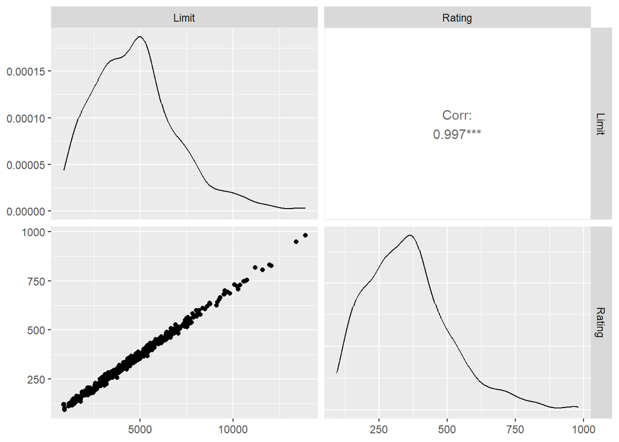

```r
Credit |>
  select(Limit, Rating) |> # add your extra variables here.
  ggpairs()
```

## Exercise 2

Fit a linear model with just `Rating` as the predictor and get the p-value associated with it’s coefficient. Is it statistically significant?

## Exercise 3

Fit a linear model with just your second quantitative predictor and get the p-value associated with it’s coefficient. Is it statistically significant?

## Exercise 6

Use `head` to look at the first observation in the data set. Use addition, subtraction, multiplication, and division to figure out what credit limit your model would predict for a person with the same characteristics of this person.

## Exercise 7

Now use the `predict` function to verify the value you computed in the previous exercise and compute a 90% prediction interval. How would you interpret this interval in context?

## Exercise 8

Fit a linear model predicting `Limit` from **ONLY** your categorical variable. What is the reference level?

## Exercise 9

WITHOUT WRITING ANY CODE except for addition, subtraction, multiplication, and addition, what would the model predict the average `Limit` to be for each of the level of your categorical variable?

## Exercise 10

Compute the average `Limit` for each level in your categorical variable. Hint: you can use “formulas” (i.e. `repsonse ~ explanatory`) in the `mean` function from the `mosaic` package. How do these answers compare to your answers from Exercise 9?

## Exercise 11

Fit a linear model using your quantitative and your categorical variable as predictors (don’t use `Rating`). Use the function `plotModel` to make a nifty plot for your model. Your syntax should look like `plotModel(model_name)`.

## Exercise 12

Your model contains one line for every level of your categorical variable. On the board, write out the equations for two of them.

## Exercise 13

How do you think the plot above will change if you add in an interaction term between your variables? **AFTER** thinking about it, add in an in the interaction term and plot the model using `plotModel`.

## Exercise 14

Your model contains one line for every level of your categorical variable. On the board, write out the equations for two of them.

## Exercise 15

Fit a model with your quantitative predictor, `Rating`, and an interaction term. Write your model on the board.

## Exercise 16 (Optional)

Look back at all of the models that you’ve fit. If you compare the p-values for the same variable across multiple models, what do you notice?

## Exercise 17 (Optional)

Note that this data set only considers borrowers who have actually been granted loans. How does this impact the generalizability of our analysis?

## To submit the AE

**Important**

- Render the document to produce the HTML file with all of your work from today’s class.
- Upload your QMD and HTML files to the Canvas assignment.